# Exploration of potential parametric forms of conditional extreme value models

## Sequential parameter estimation: other conditioning sites

We repeat the parameter estimation method described above for three other conditioning sites: Inverness, Lancaster and Newcastle.

Examine similar plots of parameter estimate iterations for a randomly picked site $j$ (set to $j=100$).

Inverness:

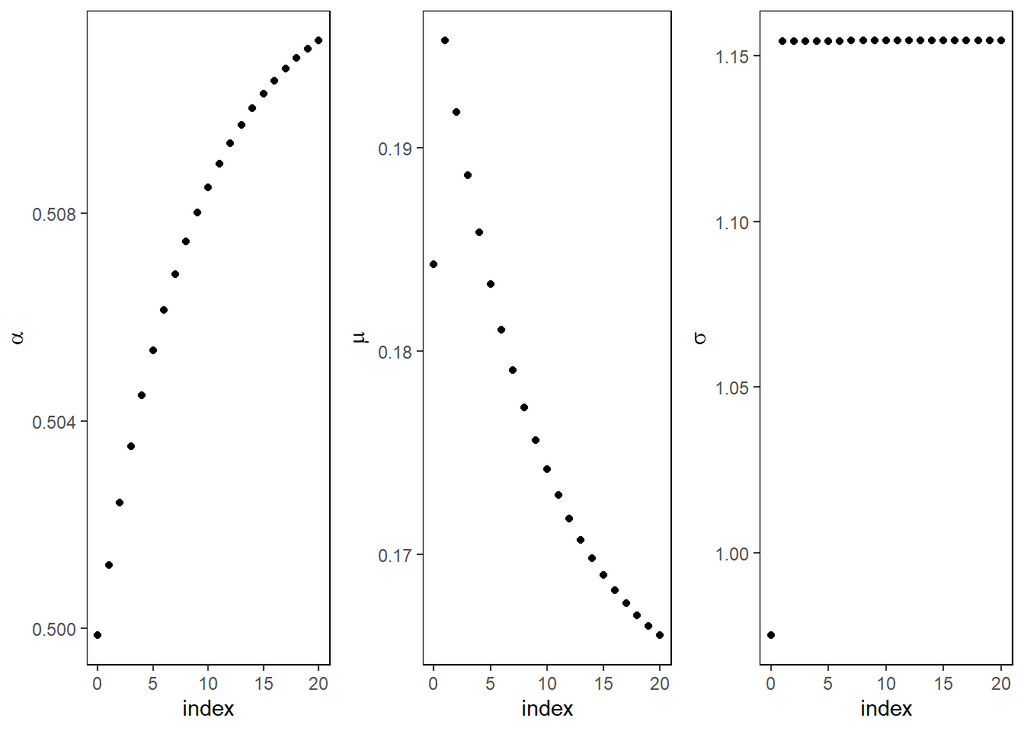

Lancaster:

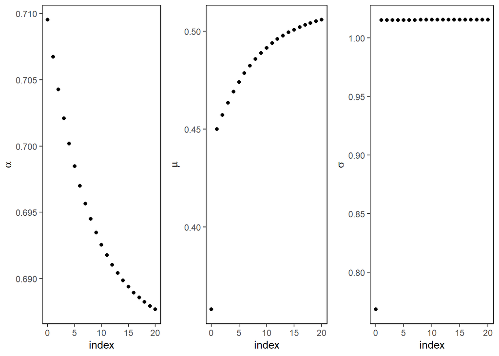

Newcastle:

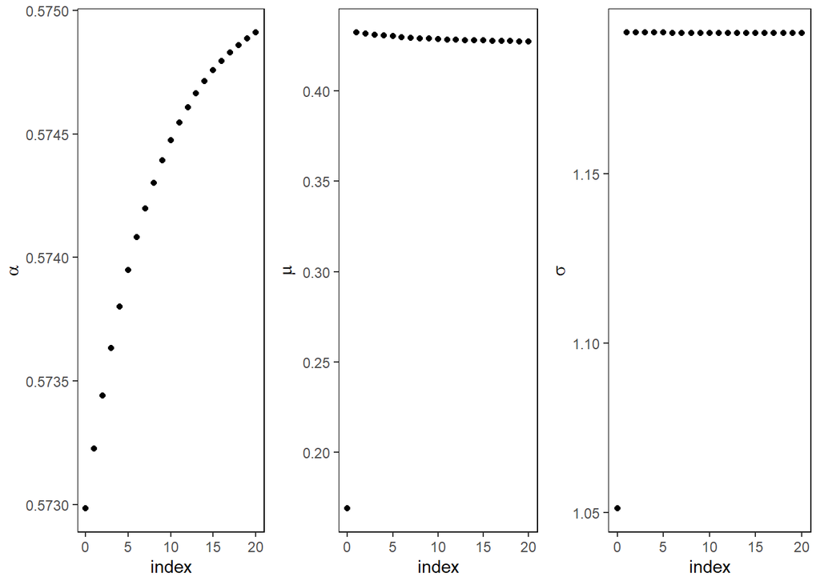

Similar to the previous section, we map the parameter estimates of the final iteration.

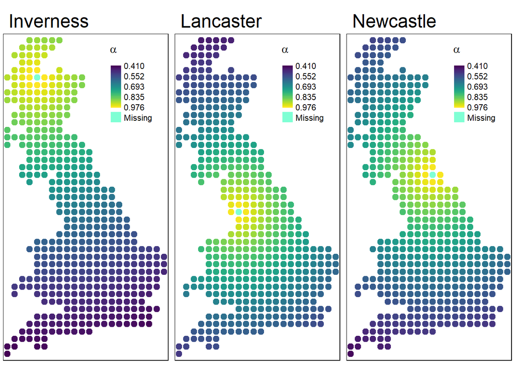

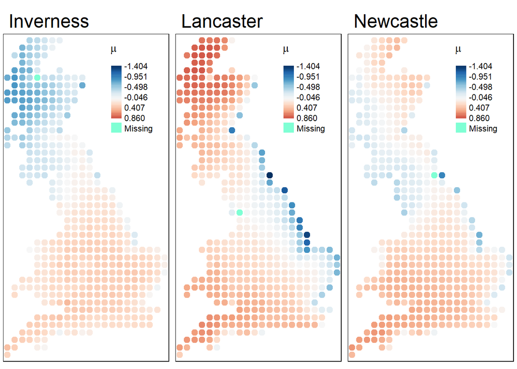

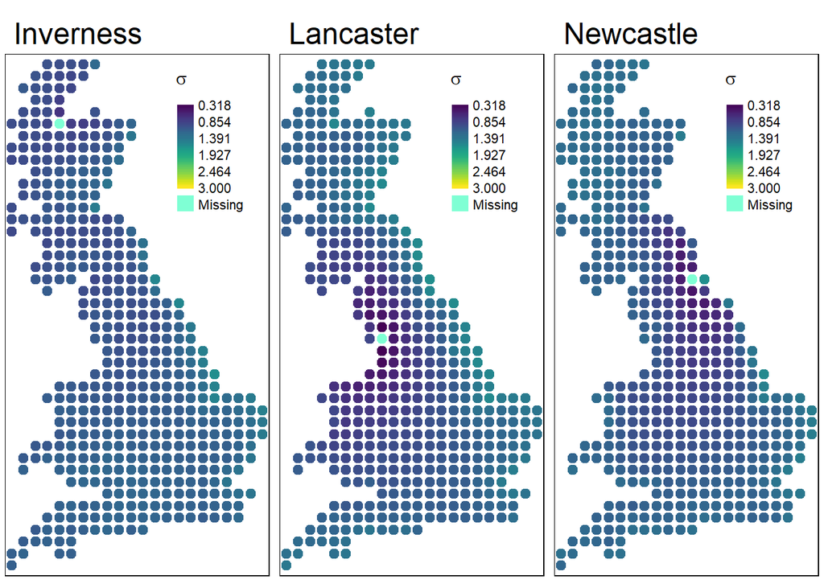

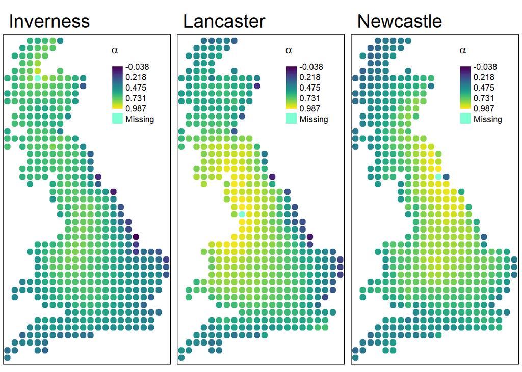

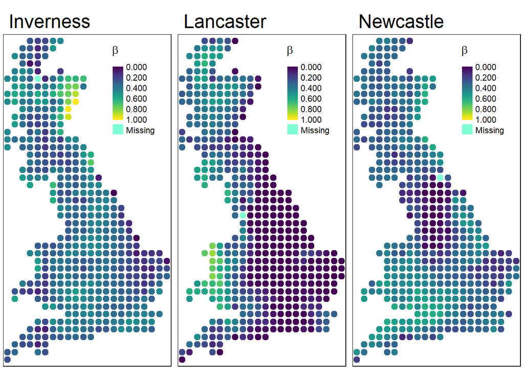

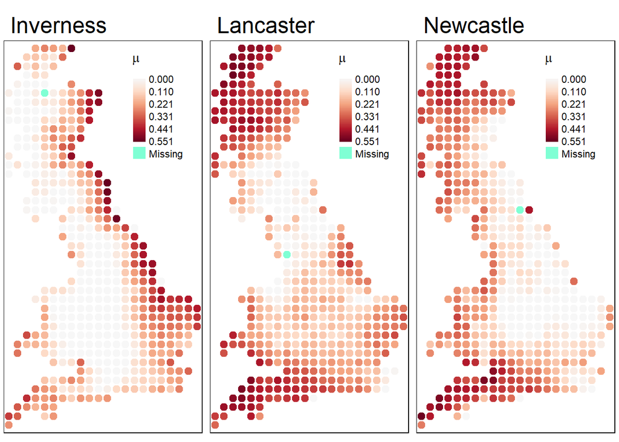

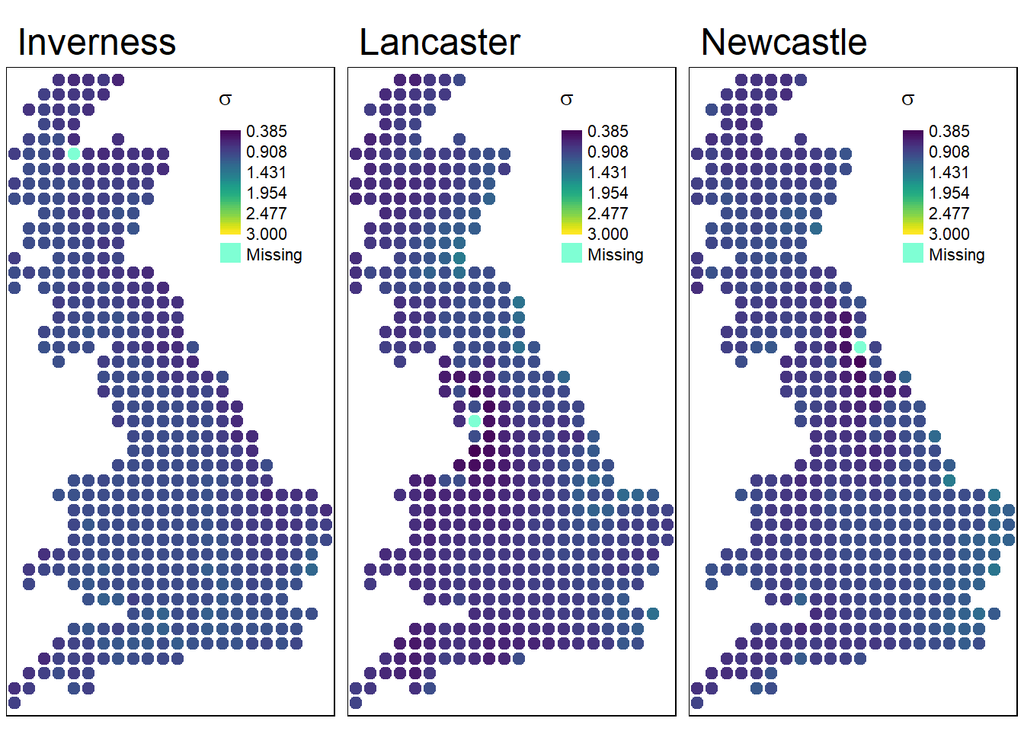

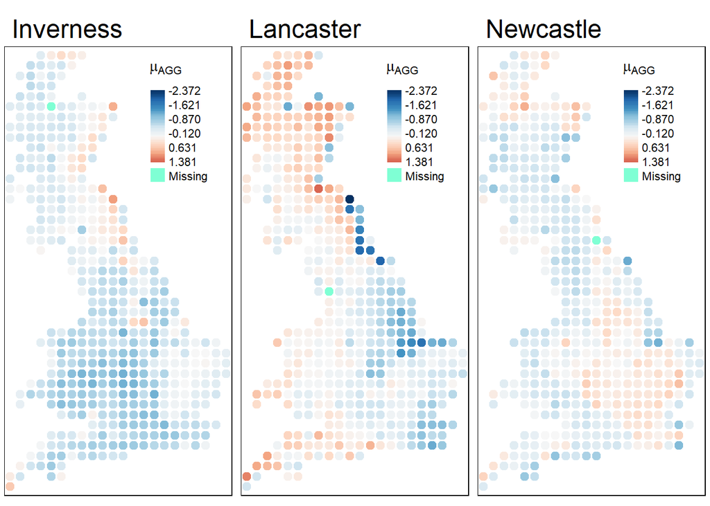

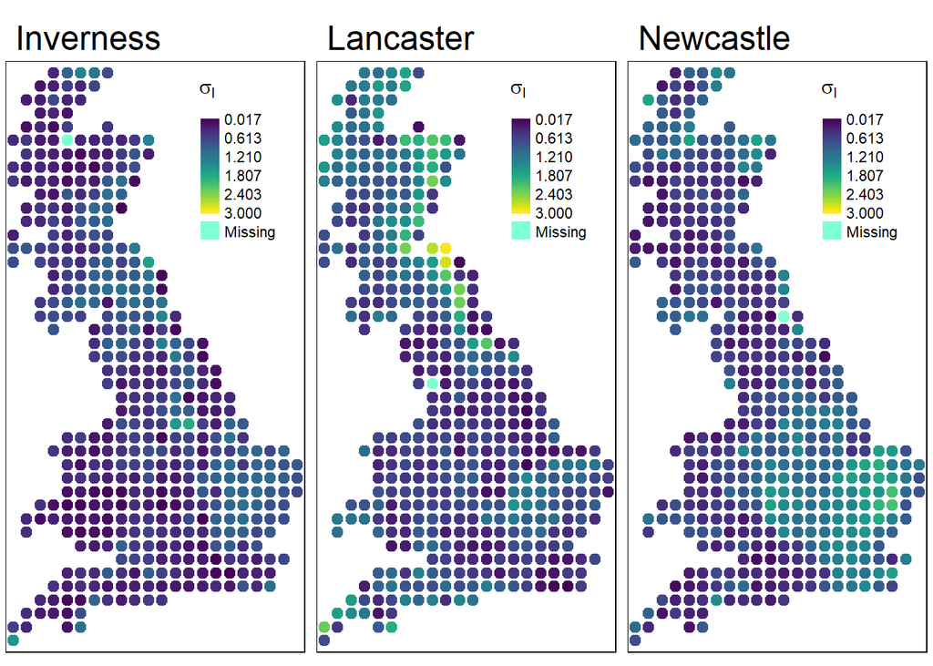

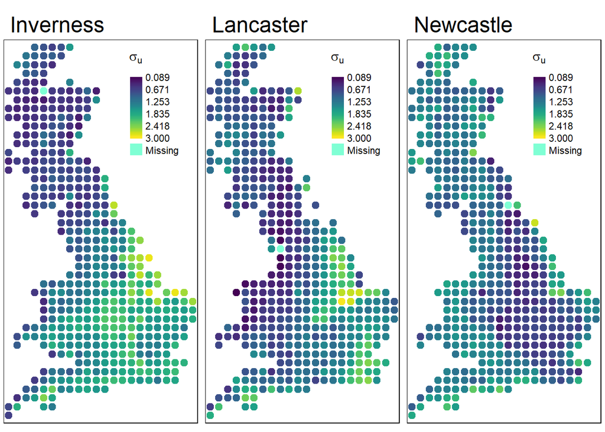

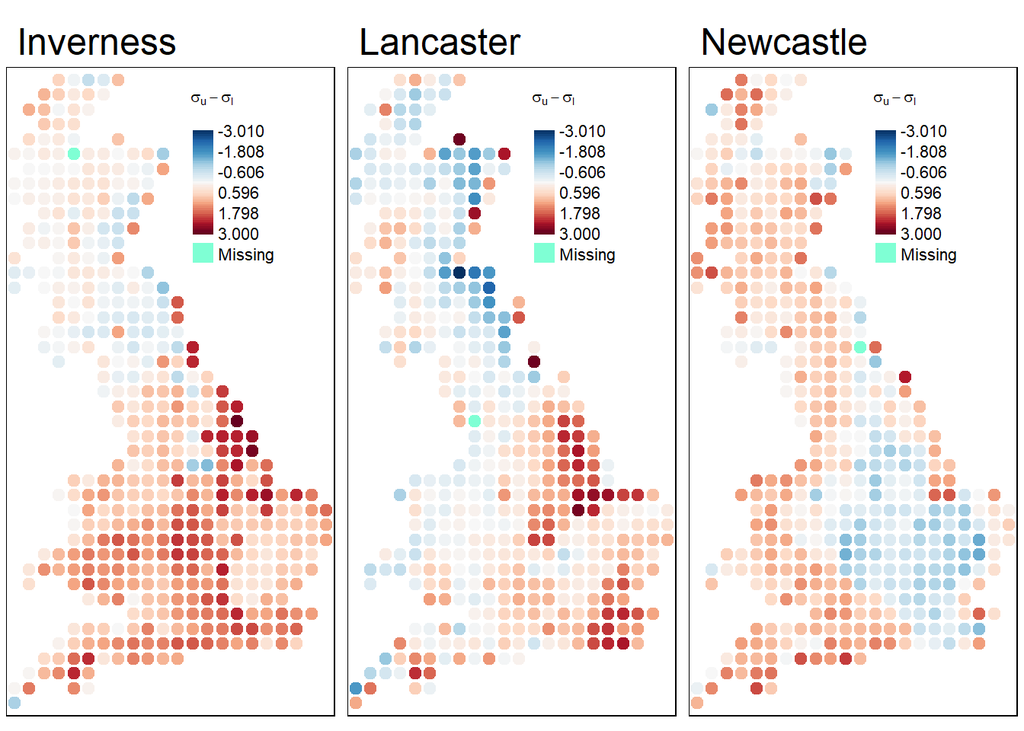

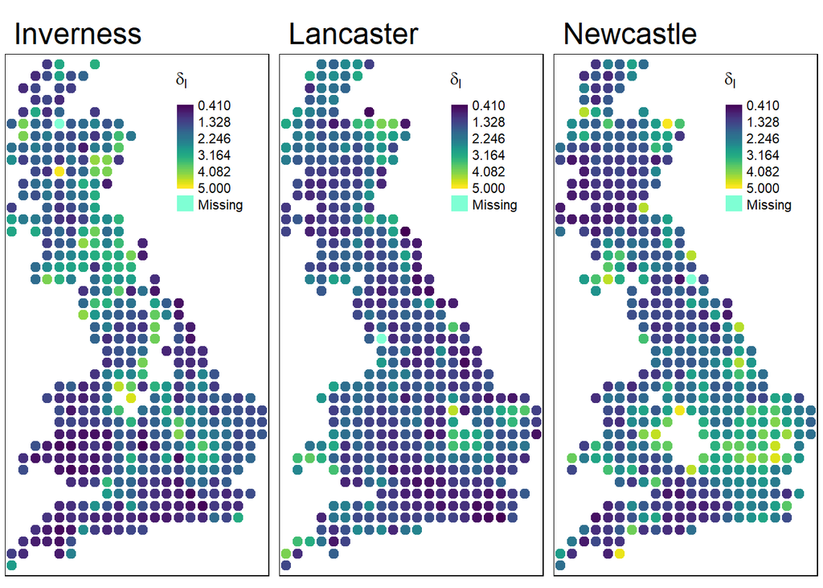

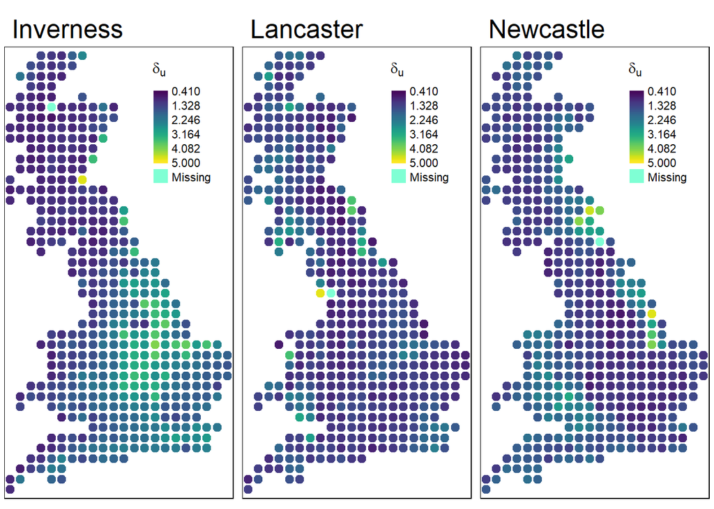

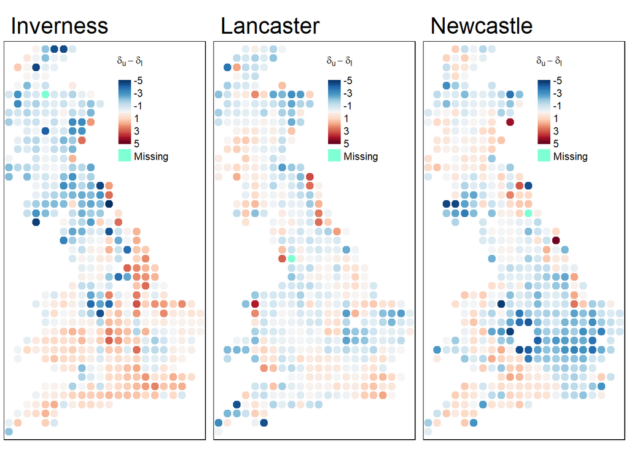

Now fit exponential to $\alpha$ estimates and find MLE for the other parameters using the sequential approach.

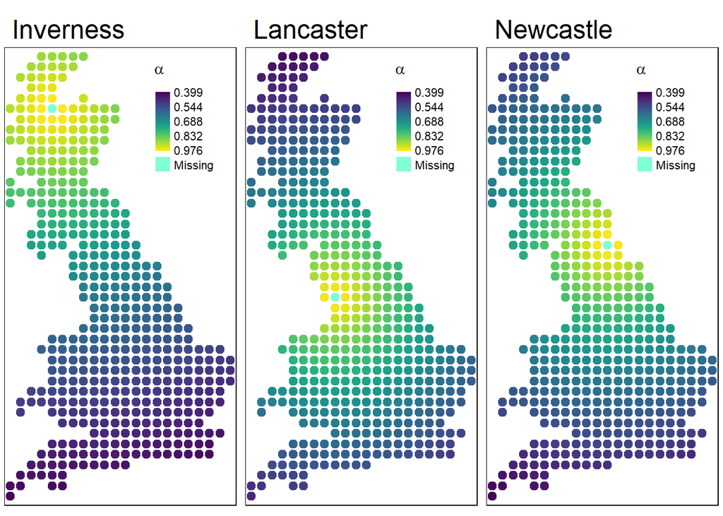

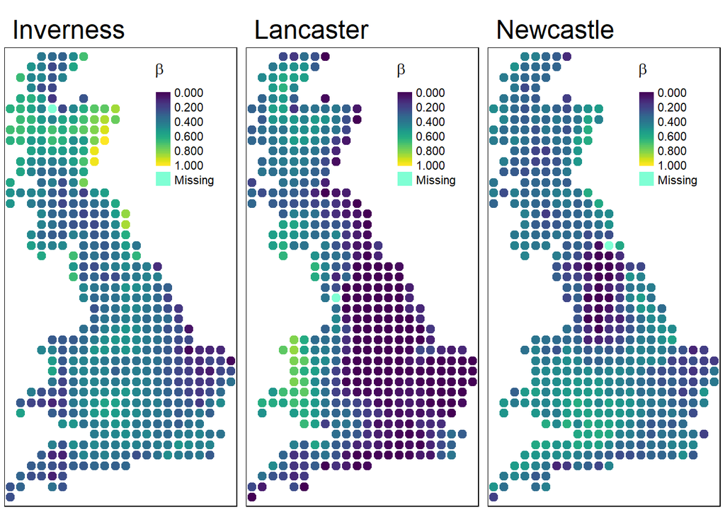

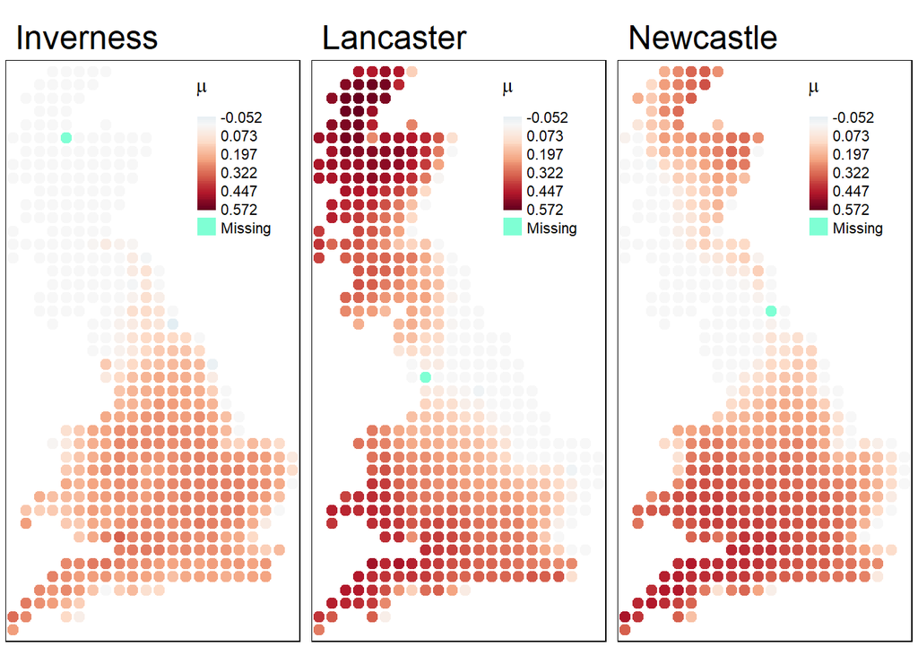

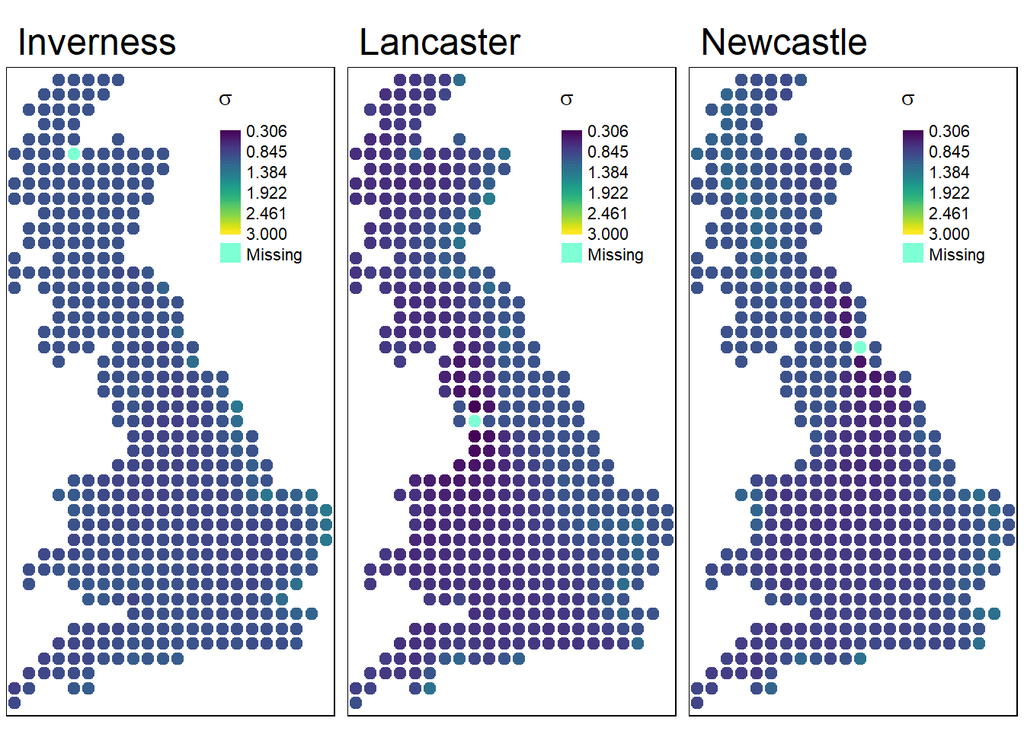

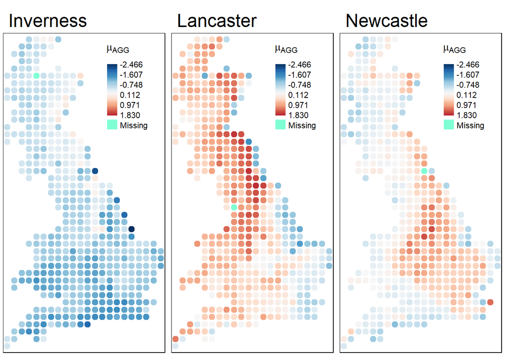

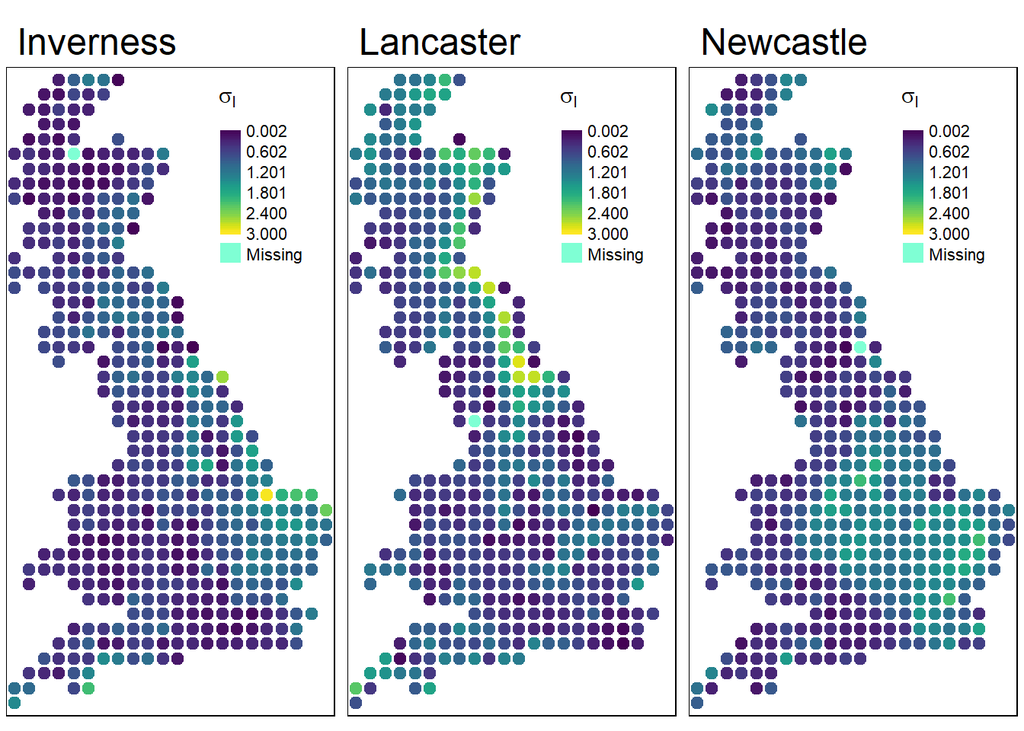

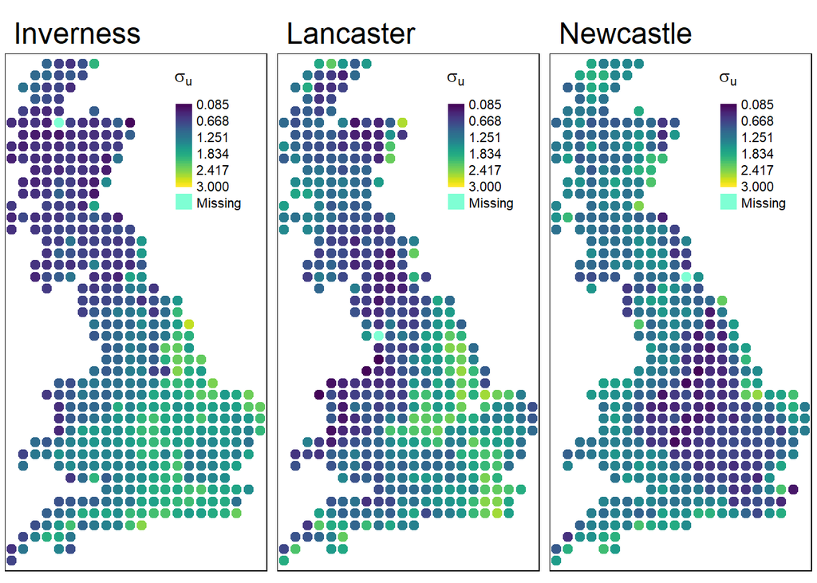

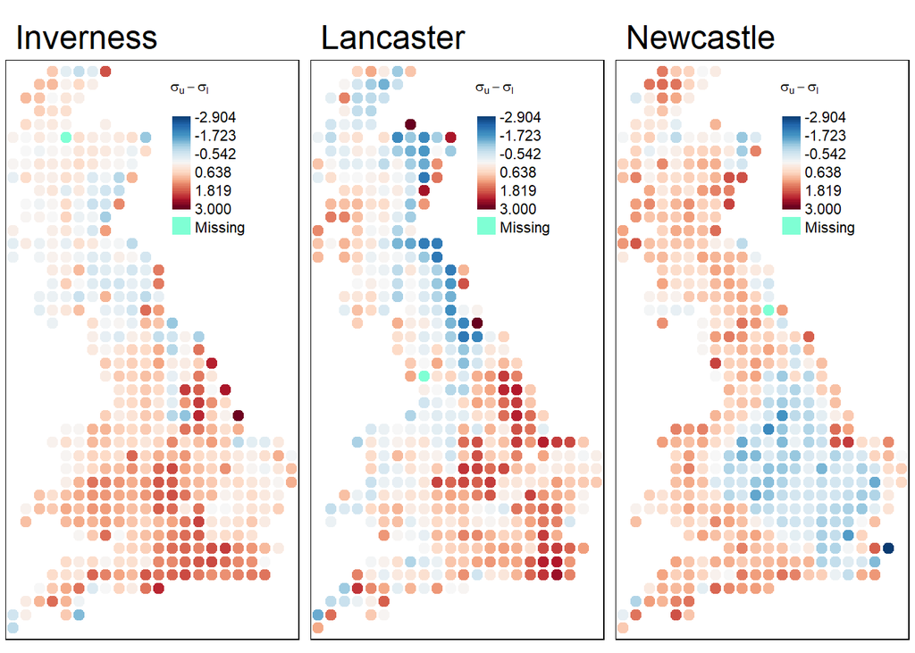

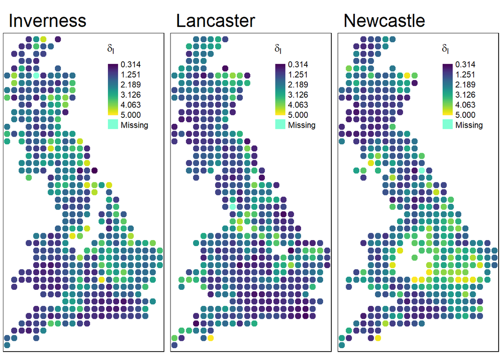

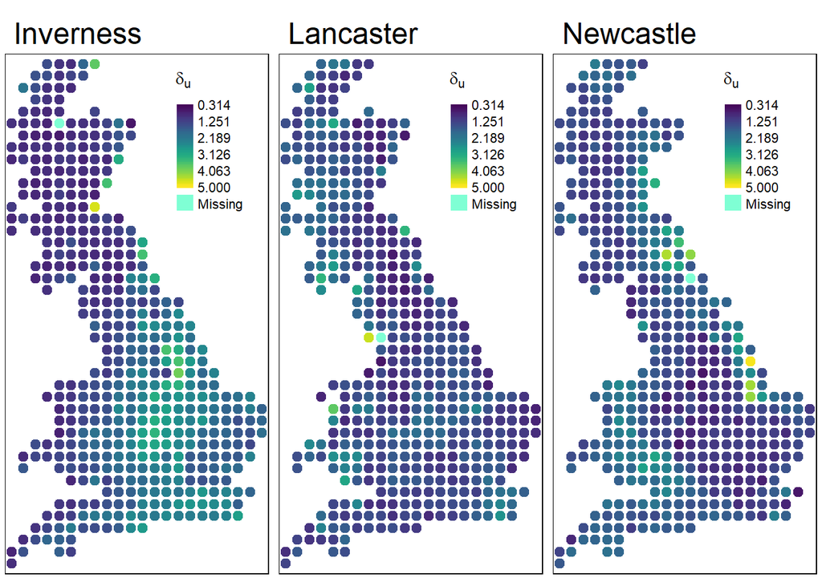

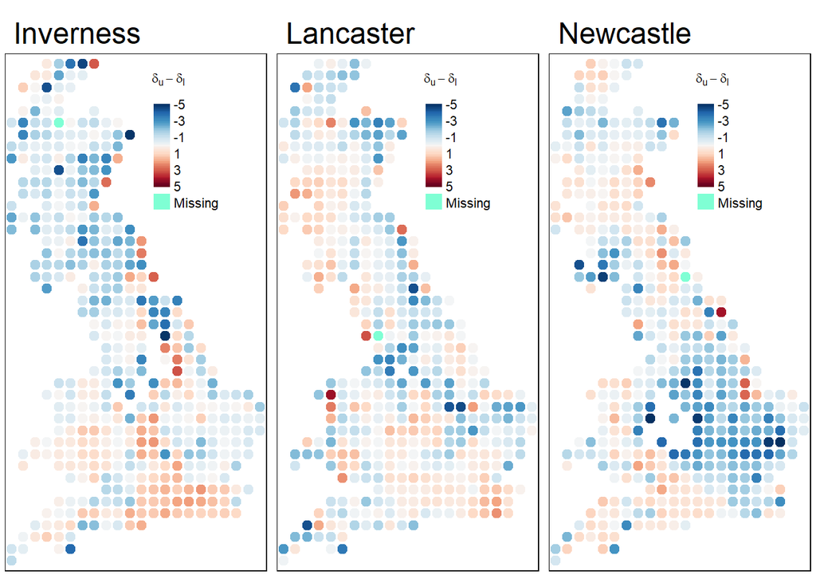

## New sites: Cromer, Hull and Lowestoft

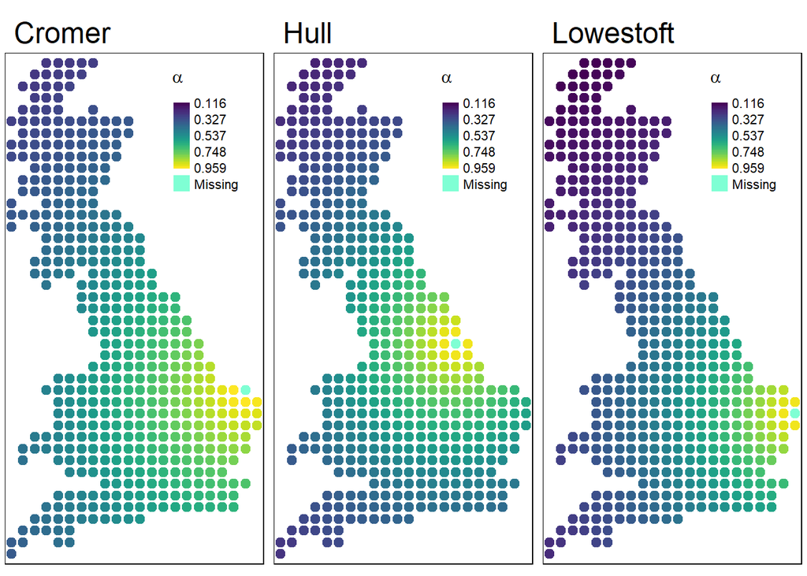

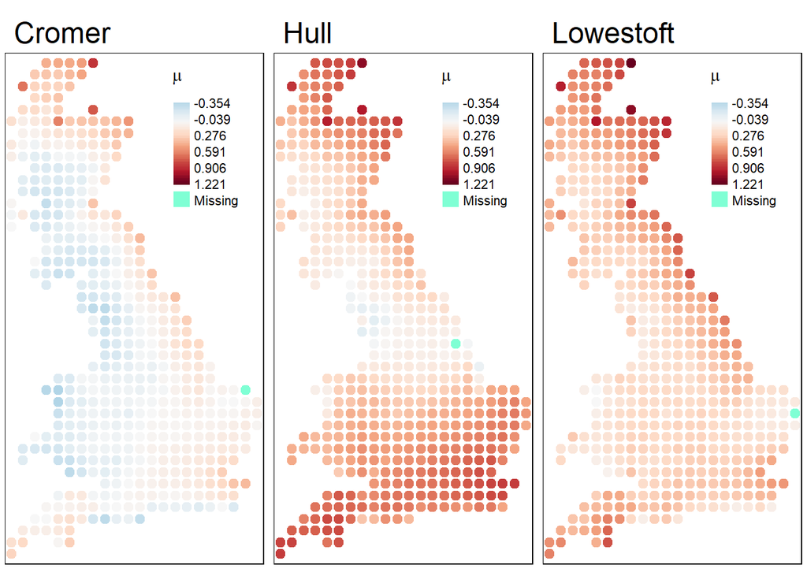

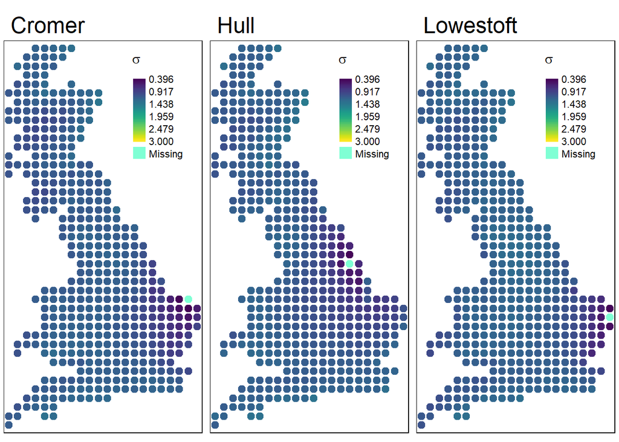

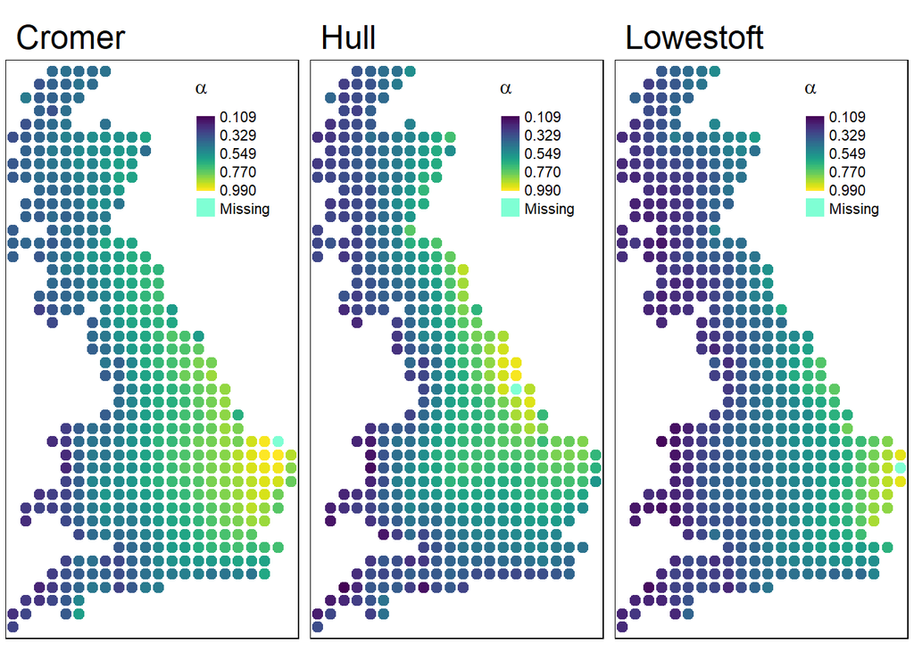

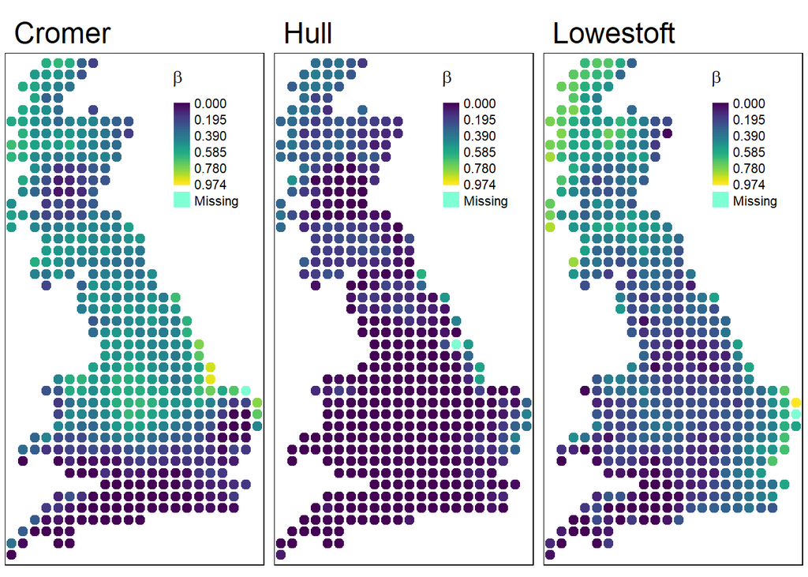

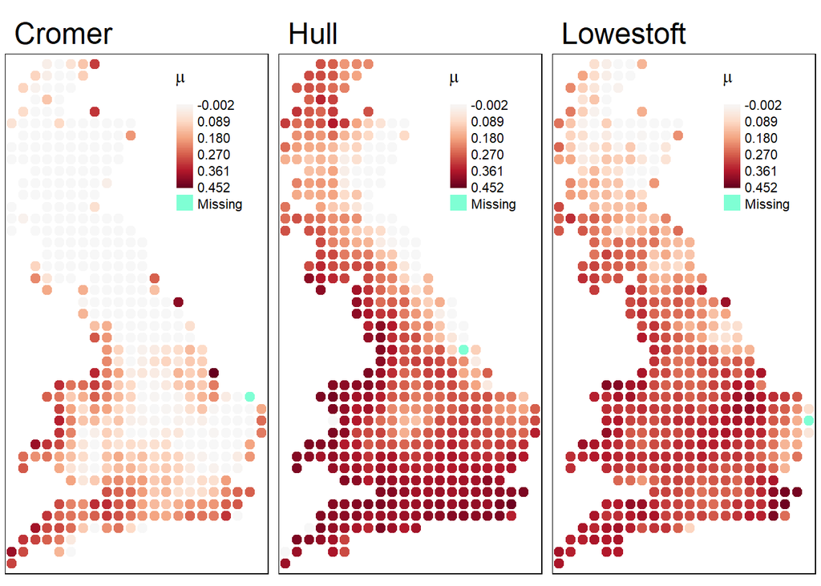

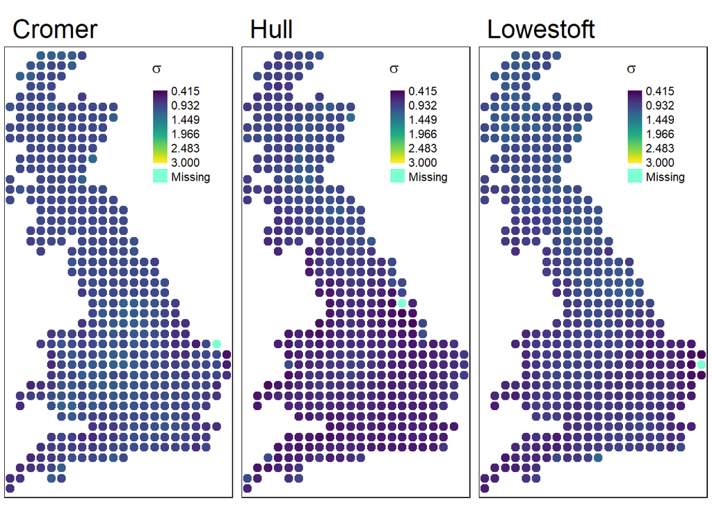

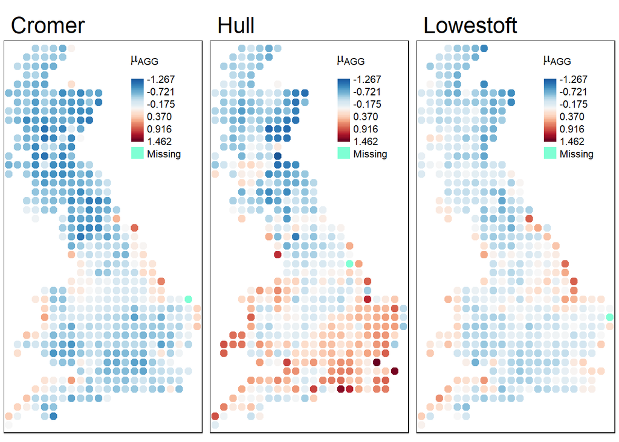

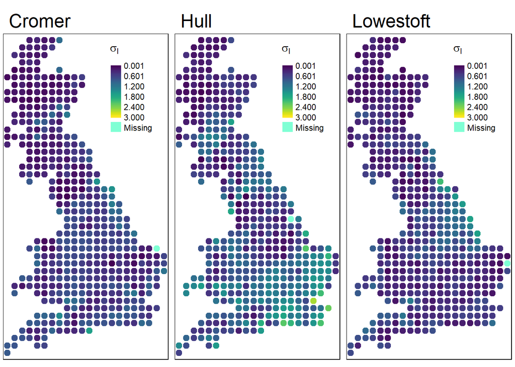

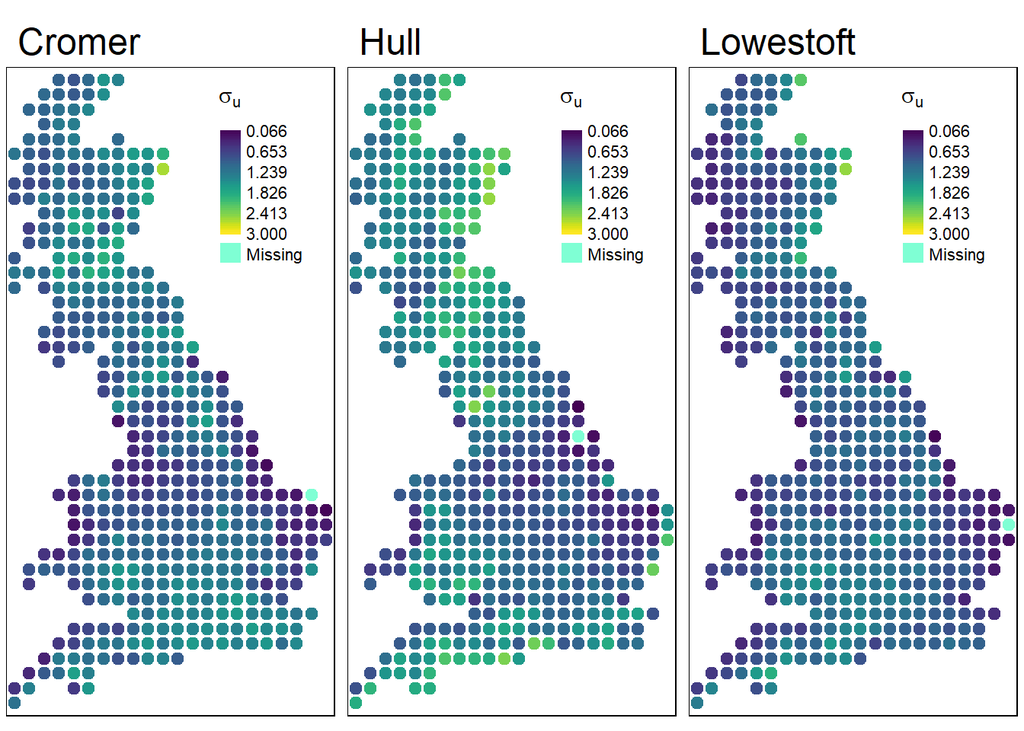

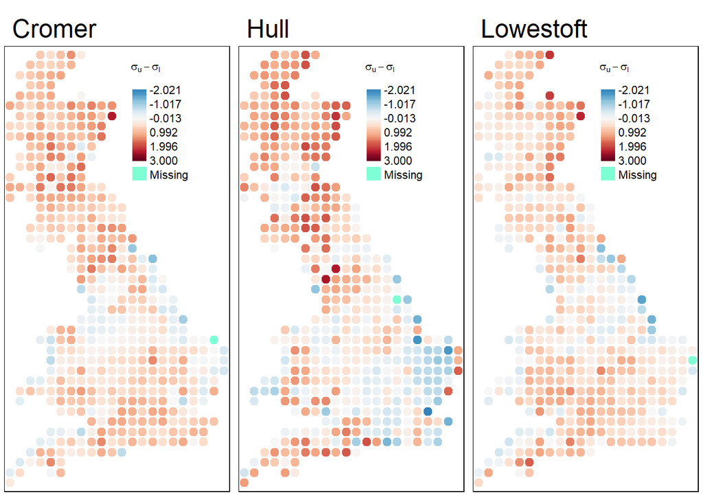

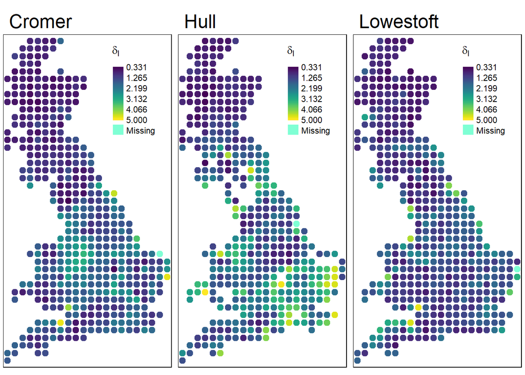

[2 more figures not shown]